# ESM 244 Lab Week 6: Clustering (k-means & hierarchical)

In this lab, you’ll learn how to do some cluster exploration by partition-based (k-means) and hierarchical clustering.

## Get & attach required packages

Note: You’ll probably need to install the last 5 packages here for clustering.

```r
library(tidyverse)
library(janitor)
library(palmerpenguins)

# Packages for cluster analysis:
library(NbClust)
library(cluster)
library(factoextra)
library(dendextend)
library(ggdendro)
```

## Intro to cluster analysis (k-means, hierarchical)

### Part 1. K-means clustering:

To practice k-means clustering, we’ll use the `penguins` dataset from `palmerpenguins`.

#### Exploratory visualization

First, do some exploratory data visualization, mapping species onto point color. Does it look like there is an opportunity to cluster by species?

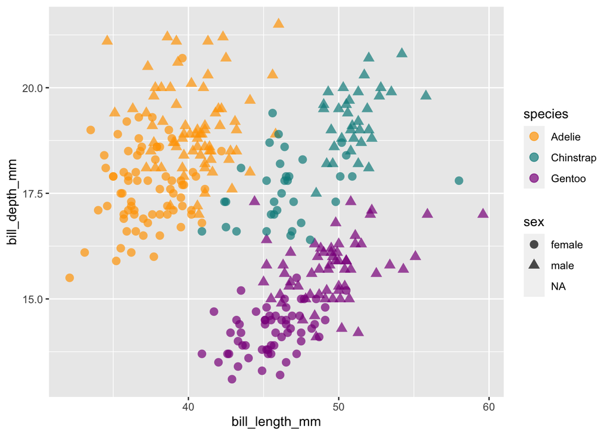

```r
# Bill length versus depth exploratory plot:
ggplot(penguins) +
  geom_point(aes(x = bill_length_mm,
                 y = bill_depth_mm,
                 color = species,
                 shape = sex),
             size = 3,
             alpha = 0.7) +
  scale_color_manual(values = c("orange","cyan4","darkmagenta"))
```

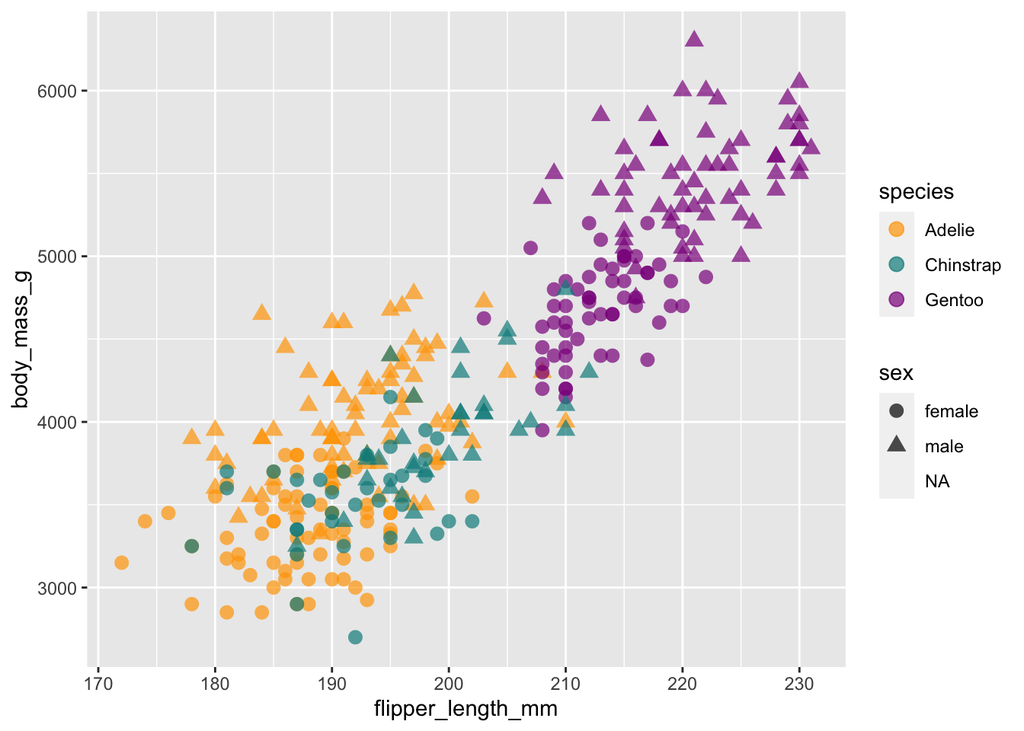

```r
# Flipper length versus body mass exploratory plot:
ggplot(penguins) +
  geom_point(aes(x = flipper_length_mm,
                 y = body_mass_g,
                 color = species,
                 shape = sex),
             size = 3,
             alpha = 0.7) +
  scale_color_manual(values = c("orange","cyan4","darkmagenta"))
```

#### Pick the number of clusters

In the Week 8 lecture, you learned that for k-means clustering you need to specify the number of clusters *a priori*. R **does** have some tools to help you decide, but this should NOT override your judgement based on conceptual or expert understanding.

Here, we use the `NbClust::NbClust()` function, which “provides 30 indices for determining the number of clusters and proposes to user the best clustering scheme from the different results obtained by varying all combinations of number of clusters, distance measures, and clustering methods”. See `?NbClust` for more information.

Basically, it’s going to run 30 different ways of evaluating how many clusters it *thinks* exist, then tell you the breakdown of what they decide (e.g. “8 algorithms think that there should be 4 clusters”).

#### Create a complete, scaled version of the data

We are going to do this with *complete cases* - in other words, for the variables we’re using to perform k-means clustering on penguins (bill length, bill depth, flipper length, body mass), we are *dropping any observation (row) where any of those are missing*. Keep in mind that this may not be the best option for every scenario - in other cases (e.g. when we have a large proportion of missingness), we may want to impute missing values instead.

```r
# Drop rows where any of the four size measurements are missing
penguins_complete <- penguins %>%
  drop_na(bill_length_mm, bill_depth_mm, body_mass_g, flipper_length_mm)

# Only keep the columns for the four size measurements, then SCALE them
penguins_scale <- penguins_complete %>%
  select(ends_with("mm"), body_mass_g) %>%
  scale() # See ?scale for details on scaling

# compare scaled to original vars
summary(penguins_complete)
```

```
##       species          island    bill_length_mm  bill_depth_mm
##  Adelie   :151   Biscoe   :167   Min.   :32.10   Min.   :13.10
##  Chinstrap: 68   Dream    :124   1st Qu.:39.23   1st Qu.:15.60
##  Gentoo   :123   Torgersen: 51   Median :44.45   Median :17.30
##                                  Mean   :43.92   Mean   :17.15
##                                  3rd Qu.:48.50   3rd Qu.:18.70
##                                  Max.   :59.60   Max.   :21.50
##  flipper_length_mm  body_mass_g       sex           year
##  Min.   :172.0     Min.   :2700   female:165   Min.   :2007
##  1st Qu.:190.0     1st Qu.:3550   male  :168   1st Qu.:2007
##  Median :197.0     Median :4050   NA's  :  9   Median :2008
##  Mean   :200.9     Mean   :4202                Mean   :2008
##  3rd Qu.:213.0     3rd Qu.:4750                3rd Qu.:2009
##  Max.   :231.0     Max.   :6300                Max.   :2009
```

```r
summary(penguins_scale)
```

```
##  bill_length_mm     bill_depth_mm      flipper_length_mm  body_mass_g
##  Min.   :-2.16535   Min.   :-2.05144   Min.   :-2.0563   Min.   :-1.8726
##  1st Qu.:-0.86031   1st Qu.:-0.78548   1st Qu.:-0.7762   1st Qu.:-0.8127
##  Median : 0.09672   Median : 0.07537   Median :-0.2784   Median :-0.1892
##  Mean   : 0.00000   Mean   : 0.00000   Mean   : 0.0000   Mean   : 0.0000
##  3rd Qu.: 0.83854   3rd Qu.: 0.78430   3rd Qu.: 0.8594   3rd Qu.: 0.6836
##  Max.   : 2.87166   Max.   : 2.20217   Max.   : 2.1395   Max.   : 2.6164
```

Make sure to check out what `penguins_scale` looks like!

#### identifying optimal number of clusters

```r
# How many clusters do you THINK there should be?
number_est <- NbClust(penguins_scale, min.nc = 2, max.nc = 10, method = "kmeans")
```

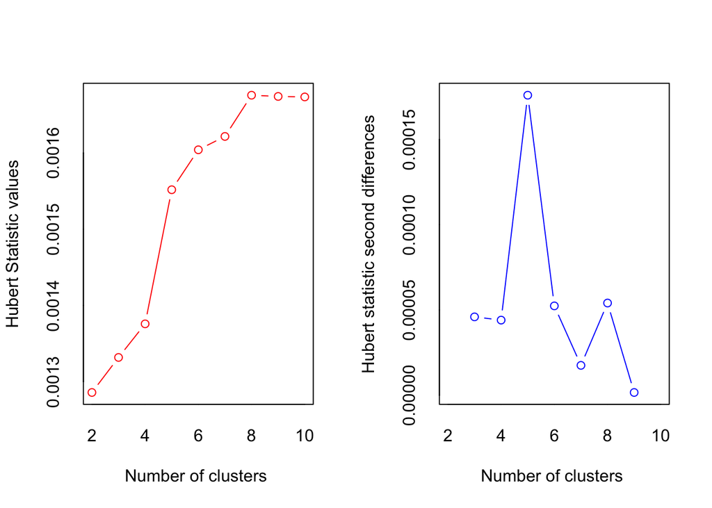

```
## *** : The Hubert index is a graphical method of determining the number of clusters.
##                 In the plot of Hubert index, we seek a significant knee that corresponds to a
##                 significant increase of the value of the measure i.e the significant peak in Hubert
##                 index second differences plot.
##
```

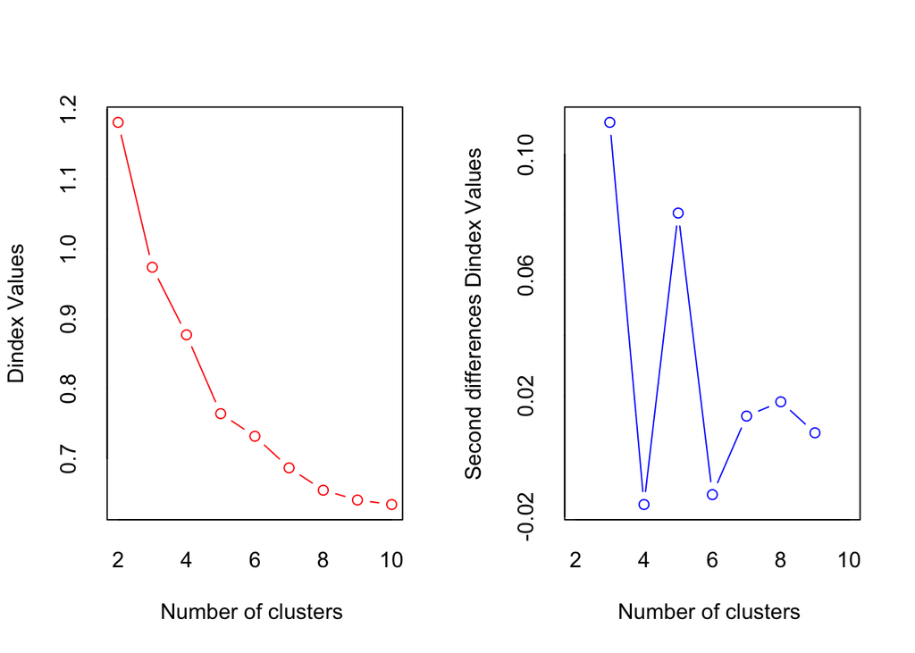

```
## *** : The D index is a graphical method of determining the number of clusters.
##                 In the plot of D index, we seek a significant knee (the significant peak in Dindex
##                 second differences plot) that corresponds to a significant increase of the value of
##                 the measure.
##
## * Among all indices:
## * 8 proposed 2 as the best number of clusters
## * 11 proposed 3 as the best number of clusters
## * 1 proposed 4 as the best number of clusters
## * 3 proposed 5 as the best number of clusters
## * 1 proposed 10 as the best number of clusters
##
##                    ***** Conclusion *****
##
## * According to the majority rule, the best number of clusters is  3
##
##
```

```r
# Check out the results (just look at the first summary report):
number_est
```

```
## $All.index
##         KL       CH Hartigan     CCC     Scott   Marriot    TrCovW   TraceW
## 2   4.0581 482.1915 164.7091  4.3875  927.1379 303068682 10949.214 564.0535
## 3   3.7940 438.9515  75.6156  7.8617 1315.0662 219334118  2940.347 379.9777
## 4   0.3579 381.9829 114.7890  8.9991 1494.4437 230779989  2103.312 310.6792
## 5  14.4992 411.2587  27.1870 13.3394 1702.2662 196386346  1963.783 231.9172
## 6   0.2182 359.9154  50.8221 11.6235 1766.9918 234035036  1968.003 214.6043
## 7   2.9439 352.7132  31.3250 12.5775 1908.3004 210732397  1843.829 186.4088
## 8   2.6637 334.0701  17.2431 12.4373 2027.2994 194357957  1541.701 170.4687
## 9   0.2295 308.6308   5.4504 11.5241 2080.8449 210335087  1536.748 162.1001
## 10  3.1777 278.5952  12.3265  9.9390 2102.1766 243971044  1490.374 159.4897
##    Friedman  Rubin Cindex     DB Silhouette   Duda Pseudot2   Beale Ratkowsky
## 2   13.5015 2.4182 0.3043 0.7735     0.5315 0.5627 168.6648  1.8679    0.5310
## 3   17.2321 3.5897 0.2754 0.9671     0.4586 1.5248 -53.6887 -0.8190    0.4901
## 4   20.0918 4.3904 0.2509 1.0237     0.4239 0.4498 148.0115  2.9289    0.4393
## 5   23.1707 5.8814 0.2703 1.0331     0.3782 0.7959  17.6902  0.6079    0.4074
## 6   24.1190 6.3559 0.2659 1.1375     0.3410 1.1777 -18.8650 -0.3587    0.3747
## 7   26.5335 7.3173 0.3006 1.1131     0.3351 1.0391  -3.0865 -0.0894    0.3512
## 8   29.2085 8.0015 0.2790 1.2242     0.2995 0.7823  10.5772  0.6522    0.3307
## 9   30.2702 8.4146 0.3140 1.2587     0.2836 1.1176  -2.9469 -0.2439    0.3129
## 10  30.7827 8.5523 0.3136 1.3753     0.2694 0.9609   1.5889  0.0953    0.2972
##        Ball Ptbiserial   Frey McClain   Dunn Hubert SDindex Dindex   SDbw
## 2  282.0268     0.7709 1.0312  0.4077 0.2722 0.0013  2.0393 1.1814 0.4349
## 3  126.6592     0.7372 1.6556  0.7581 0.0760 0.0013  1.9232 0.9740 0.2881
## 4   77.6698     0.6552 0.5939  1.1174 0.0505 0.0014  2.1348 0.8771 0.3244
## 5   46.3834     0.6190 2.6653  1.4290 0.0636 0.0016  1.9711 0.7642 0.5074
## 6   35.7674     0.5864 0.4736  1.6265 0.0636 0.0016  2.3999 0.7318 0.4183
## 7   26.6298     0.5722 0.9576  1.7617 0.0594 0.0016  2.3349 0.6866 0.1350
## 8   21.3086     0.5224 0.5909  2.1922 0.0799 0.0017  2.4462 0.6546 0.1295
## 9   18.0111     0.5155 5.3931  2.2634 0.0910 0.0017  2.4356 0.6405 0.1210
## 10  15.9490     0.5089 2.0533  2.3283 0.0910 0.0017  3.6230 0.6341 0.1160
##
## $All.CriticalValues
##    CritValue_Duda CritValue_PseudoT2 Fvalue_Beale
## 2          0.7043            91.1023       0.1140
## 3          0.6011           103.5439       1.0000
## 4          0.6587            62.7059       0.0206
## 5          0.5732            51.3723       0.6574
## 6          0.5902            86.7814       1.0000
## 7          0.5842            58.3534       1.0000
```

[output cut: 14 more lines]

```
##                   Dunn Hubert SDindex Dindex   SDbw
## Number_clusters 2.0000      0  3.0000      0 10.000
## Value_Index     0.2722      0  1.9232      0  0.116
##
## $Best.partition
##   [1] 3 3 3 3 3 3 3 3 3 3 3 3 3 3 3 3 1 3 1 3 3 3 3 3 3 3 3 3 3 3 3 3 3 3 3 3 3
##  [38] 3 3 3 3 3 1 3 3 3 3 3 3 3 3 3 3 3 3 3 3 3 3 3 3 3 3 3 3 3 3 3 3 3 3 3 1 3
##  [75] 3 3 3 3 3 3 1 3 3 3 3 3 3 3 3 3 3 3 3 3 3 3 3 3 3 3 3 3 3 3 3 3 3 3 1 3 1
## [112] 3 3 3 3 3 3 3 3 3 3 3 3 3 3 3 3 3 1 3 3 3 3 3 3 3 3 3 3 3 3 3 3 3 3 3 3 3
## [149] 3 3 3 2 2 2 2 2 2 2 2 2 2 2 2 2 2 2 2 2 2 2 2 2 2 2 2 2 2 2 2 2 2 2 2 2 2
## [186] 2 2 2 2 2 2 2 2 2 2 2 2 2 2 2 2 2 2 2 2 2 2 2 2 2 2 2 2 2 2 2 2 2 2 2 2 2
## [223] 2 2 2 2 2 2 2 2 2 2 2 2 2 2 2 2 2 2 2 2 2 2 2 2 2 2 2 2 2 2 2 2 2 2 2 2 2
## [260] 2 2 2 2 2 2 2 2 2 2 2 2 2 2 2 1 1 1 1 1 1 1 1 1 1 1 1 1 1 1 1 1 1 1 1 3 1
## [297] 3 1 1 1 1 1 1 1 3 1 3 1 1 1 1 1 1 1 1 1 1 1 1 1 1 1 1 1 1 1 1 1 3 1 1 1 1
## [334] 1 1 1 1 1 1 1 1 1
```

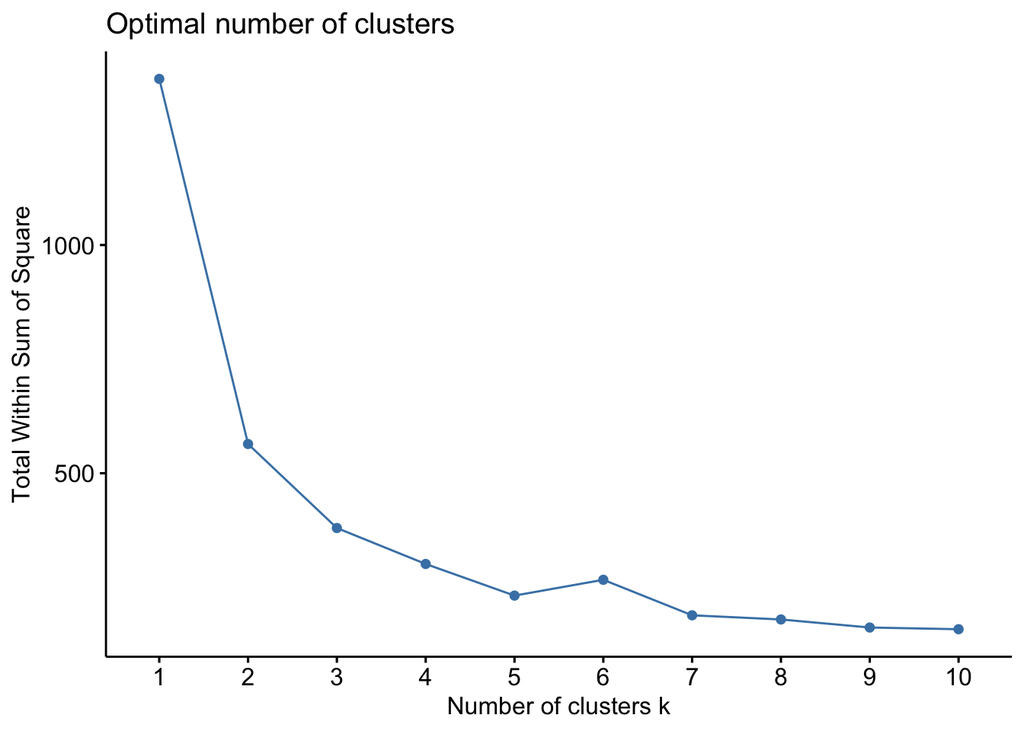

```r
# By these estimators, 3 is identified as the best number of clusters by the largest number of algorithms (11 / 24)...  could we override this?  here I think it makes sense to stick with 3 (a cluster for each species) and see how it does.

### knee method
fviz_nbclust(penguins_scale, FUNcluster = kmeans, method = 'wss', k.max = 10)
```

We’re going to use 3 clusters and see how it does, though there may be a case here for 2 given that Adelie & chinstrap penguins are pretty similar.

#### Run k-means

Now that we have complete, scaled data for the four size variables of interest, let’s run k-means. You should know the iterative process it’s running through from the Week 6 lecture.

```r
penguins_km <- kmeans(penguins_scale, 3, nstart = 25) # kmeans specifying 3 groups to start
```

Check out the outputs in `penguins_km`:

```r
# See what it returns (different elements returned by kmeans function):
penguins_km$size # How many observations assigned to each cluster
```

```
## [1] 123 132  87
```

```r
penguins_km$cluster # What cluster each observation in penguins_scale is assigned to
```

```
##   [1] 2 2 2 2 2 2 2 2 3 2 2 2 2 2 2 2 3 2 3 2 2 2 2 2 2 2 2 2 2 2 2 2 2 2 2 2 2
##  [38] 2 2 2 2 2 3 2 2 2 2 2 3 2 2 2 3 2 2 2 2 2 2 2 3 2 2 2 2 2 2 2 3 2 2 2 3 2
##  [75] 3 2 2 2 3 2 3 2 2 2 2 2 2 2 2 2 3 2 2 2 3 2 2 2 3 2 3 2 2 2 2 2 2 2 3 2 3
## [112] 2 3 2 3 2 2 2 2 2 2 2 3 2 2 2 2 2 3 2 3 2 2 2 2 2 2 2 2 2 2 2 2 2 2 2 2 2
## [149] 2 2 3 1 1 1 1 1 1 1 1 1 1 1 1 1 1 1 1 1 1 1 1 1 1 1 1 1 1 1 1 1 1 1 1 1 1
## [186] 1 1 1 1 1 1 1 1 1 1 1 1 1 1 1 1 1 1 1 1 1 1 1 1 1 1 1 1 1 1 1 1 1 1 1 1 1
## [223] 1 1 1 1 1 1 1 1 1 1 1 1 1 1 1 1 1 1 1 1 1 1 1 1 1 1 1 1 1 1 1 1 1 1 1 1 1
## [260] 1 1 1 1 1 1 1 1 1 1 1 1 1 1 1 3 3 3 3 3 3 3 3 3 3 3 3 3 3 3 3 3 3 3 3 2 3
## [297] 2 3 3 3 3 3 3 3 2 3 2 3 3 3 3 3 3 3 3 3 3 3 3 3 3 3 3 3 3 3 3 3 2 3 3 3 3
## [334] 3 3 3 3 3 3 3 3 3
```

```r
# Bind the cluster number to the original data used for clustering, so that we can see what cluster each penguin is assigned to
penguins_cl <- data.frame(penguins_complete,
                          cluster_no = factor(penguins_km$cluster))
```

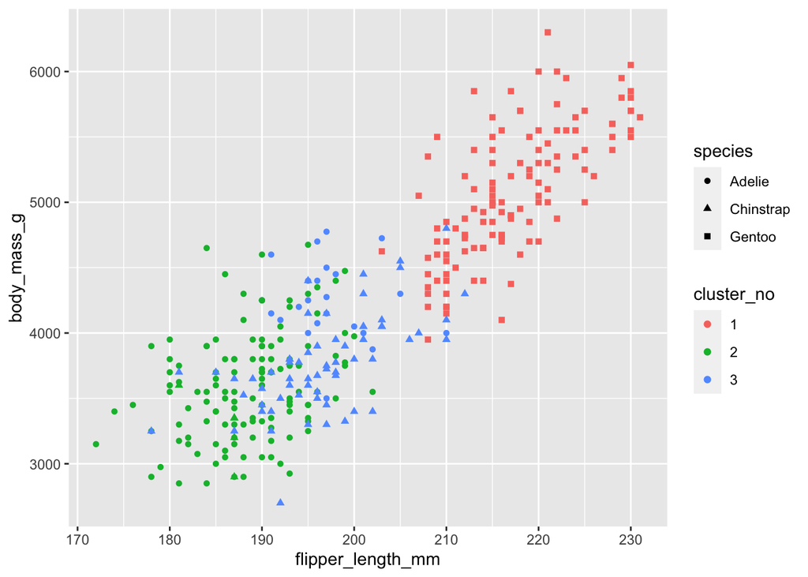

```r
# Plot flipper length versus body mass, indicating which cluster each penguin is assigned to (but also showing the actual species):
ggplot(penguins_cl) +
  geom_point(aes(x = flipper_length_mm,
                 y = body_mass_g,
                 color = cluster_no,
                 shape = species))
```

```r
# On your own: do the same, plotting bill dimensions and mapping species & cluster number to the point shape and color aesthetics:

# MAKE
# YOUR
# GRAPH
# HERE
```

What do we see from this graph?

```r
### how well does this clustering match up to species?  Select the species and
### cluster number vars and make into a continency table
penguins_cl %>% select(species, cluster_no) %>% table()
```

```
##            cluster_no
## species       1   2   3
##   Adelie      0 127  24
##   Chinstrap   0   5  63
##   Gentoo    123   0   0
```

That’s your intro to k-means clustering with penguins!

### Part 2. Cluster analysis: hierarchical

In this section, you’ll be performing hierarchical cluster analysis (& making dendrograms) in R. You should have already watched the Week 8 lecture to understand agglomerative versus divisive clustering, as well as differences in linkages (complete, single, average).

We will use the `stats::hclust()` function for agglomerative hierarchical clustering, first checking how well our clusters compare to using WorldBank environmental data (simplified), wb_env.csv.

### Compare hclust results to kmeans using penguins

Start with complete linkage… First step, create a Euclidean distance matrix

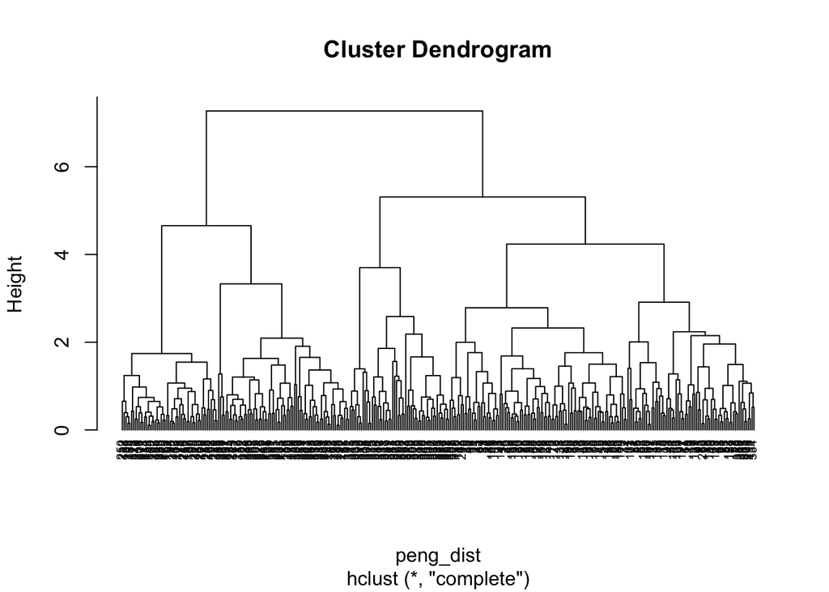

```r
peng_dist <- dist(penguins_scale, method = 'euclidean') ### look at upper and diag arguments

# Hierarchical clustering (complete linkage)
peng_hc_complete <- hclust(peng_dist, method = "complete")

# Plot it (base plot):
plot(peng_hc_complete, cex = 0.6, hang = -1)
```

```r
# use cutree to slice it into three clusters
peng_cut_hc <- cutree(peng_hc_complete, 3)
table(peng_cut_hc, penguins_complete$species)
```

```
##
## peng_cut_hc Adelie Chinstrap Gentoo
##           1    151        14      0
##           2      0         0    123
##           3      0        54      0
```

What if we tried single, average, or ward.D linkage?

How is clustering in this way (either k-means or hierarchical) different from classification using something like binary logistic regression?

### World Bank data: Read in the data, & simplify

Here, we’ll read in the WorldBank environmental data (simplified), and keep only the top 20 GHG emitters for this dataset.

```r
# Get the data
wb_env <- read_csv(here::here("data/wb_env.csv"))

# Make sure to take a look at the data:
# View(wb_env)

# Only keep top 20 greenhouse gas emitters (for simplifying visualization here...)
wb_ghg_20 <- wb_env %>%
  arrange(-ghg) %>%
  head(20)

summary(wb_ghg_20)
```

```
##      name              region           electricity         agland
##  Length:20          Length:20          Min.   :  9.80   Min.   : 6.958
##  Class :character   Class :character   1st Qu.: 99.15   1st Qu.:27.577
##  Mode  :character   Mode  :character   Median :100.00   Median :45.913
##                                        Mean   : 90.66   Mean   :39.544
##                                        3rd Qu.:100.00   3rd Qu.:52.119
##                                        Max.   :100.00   Max.   :71.194
##       co2             methane             ghg
##  Min.   :    264   Min.   :  31985   Min.   :  421228
##  1st Qu.: 343841   1st Qu.:  64401   1st Qu.:  505947
##  Median : 446534   Median :  99525   Median :  694083
##  Mean   :1223068   Mean   : 253249   Mean   : 1796822
##  3rd Qu.: 862051   3rd Qu.: 275025   3rd Qu.: 1663643
##  Max.   :8776040   Max.   :1642260   Max.   :11183811
```

#### Scale the data

```r
# Scale the numeric variables (columns 3:7)
wb_scaled <- wb_ghg_20 %>%
  select(3:7) %>%
  scale()
summary(wb_scaled)
```

```
##   electricity          agland             co2             methane
##  Min.   :-3.3375   Min.   :-1.7406   Min.   :-0.5746   Min.   :-0.58700
##  1st Qu.: 0.3502   1st Qu.:-0.6392   1st Qu.:-0.4132   1st Qu.:-0.50100
##  Median : 0.3854   Median : 0.3402   Median :-0.3649   Median :-0.40782
##  Mean   : 0.0000   Mean   : 0.0000   Mean   : 0.0000   Mean   : 0.00000
##  3rd Qu.: 0.3854   3rd Qu.: 0.6717   3rd Qu.:-0.1696   3rd Qu.: 0.05777
##  Max.   : 0.3854   Max.   : 1.6906   Max.   : 3.5492   Max.   : 3.68494
##       ghg
##  Min.   :-0.51478
##  1st Qu.:-0.48308
##  Median :-0.41268
##  Mean   : 0.00000
##  3rd Qu.:-0.04984
##  Max.   : 3.51286
```

```r
# Update to add rownames (country name) from wb_ghg_20
rownames(wb_scaled) <- wb_ghg_20$name

# Check the outcome with View(wb_scaled) - see that the rownames are now the country name (this is useful for visualizing)
```

Great, now we have a simplified, scaled version of the numeric variables, with rownames containing the county name.

#### Find the Euclidean distances

Use the `stats::dist()` function to find the Euclidean distance in multivariate space between the different observations (countries):

```r
# Compute dissimilarity values (Euclidean distances):
euc_distance <- dist(wb_scaled, method = "euclidean") ### add diag and upper

# Check out the output:
# euc_distance
```

Note: so like you saw in lecture, you *could* manually create the dendrogram using those distances! But it would take a pretty long time, so instead…

#### Perform hierarchical clustering by complete linkage with `stats::hclust()`

The `stats::hclust()` function performs hierarchical clustering, given a dissimilarity matrix (our matrix of euclidean distances), using a linkage that you specify.

Here, let’s use complete linkage (recall from lecture: clusters are merged by the smallest *maximum* distance between two observations in distinct clusters).

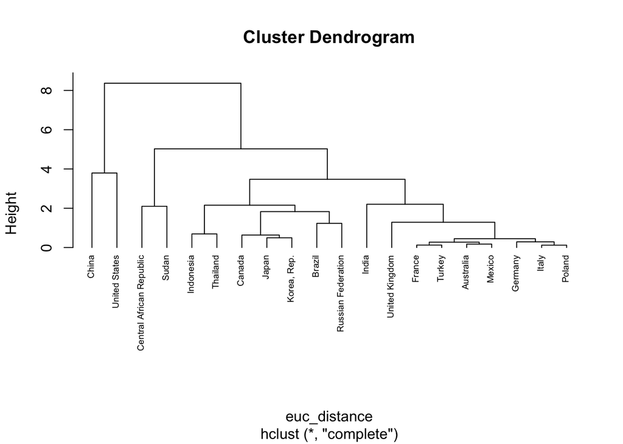

```r
# Hierarchical clustering (complete linkage)
hc_complete <- hclust(euc_distance, method = "complete" )

# Plot it (base plot):
plot(hc_complete, cex = 0.6, hang = -1)
```

### Now let’s do it by single linkage & compare

Let’s update the linkage to single linkage (recall from lecture: this means that clusters are merged by the *smallest* distance between observations in separate clusters):

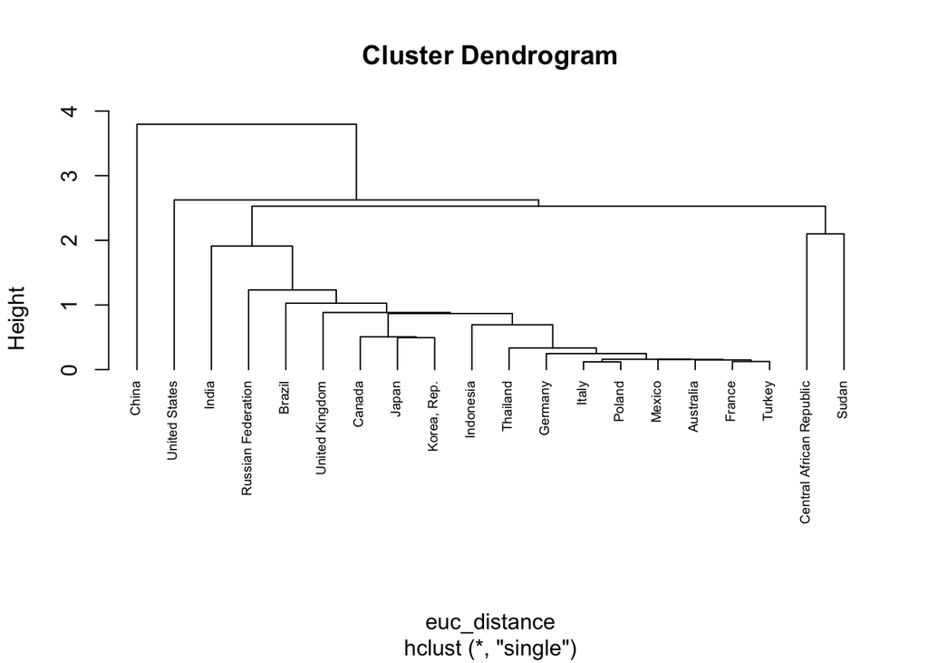

```r
# Hierarchical clustering (single linkage)
hc_single <- hclust(euc_distance, method = "single" )

# Plot it (base plot):
plot(hc_single, cex = 0.6, hang = -1)
```

We see that it is a bit different when we change the linkage! But how different?

#### Make a tanglegram to compare dendrograms

Let’s make a **tanglegram** to compare clustering by complete and single linkage! We’ll use the `dendextend::tanglegram()` function to make it.

First, we’ll convert to class `dendrogram`, then combine them into a list:

```r
# Convert to class dendrogram
dend_complete <- as.dendrogram(hc_complete)
dend_simple <- as.dendrogram(hc_single)
```

Cool, now make a tanglegram:

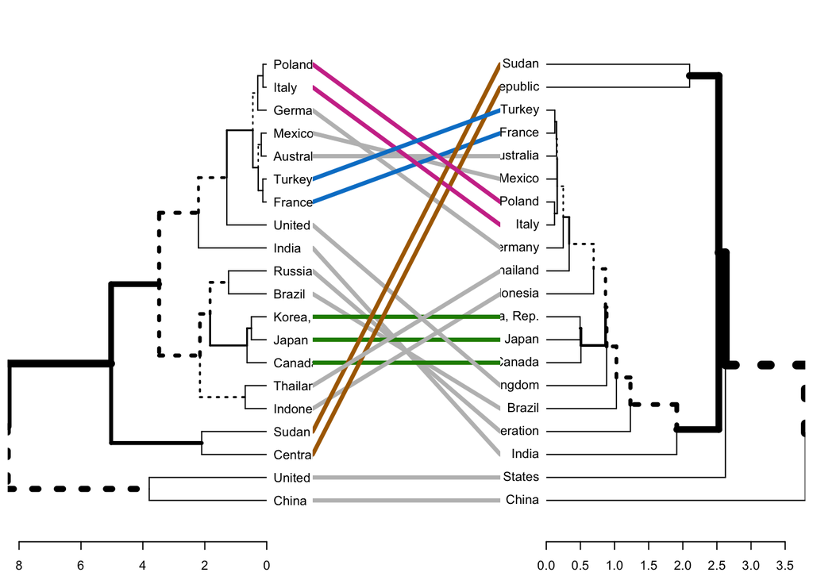

```r
# Make a tanglegram
tanglegram(dend_complete, dend_simple)
```

That allows us to compare how things are clustered by the different linkages!

Untangling:

```r
entanglement(dend_complete, dend_simple) # lower is better
```

```
## [1] 0.3959222
```

```
#> [1] 0.3959222
```

```r
untangle(dend_complete, dend_simple, method = "step1side") %>%
  entanglement()
```

```
## [1] 0.06415907
```

```r
# [1] 0.06415907
```

Notice that just because we can get two trees to have horizontal connecting lines, it doesn’t mean these trees are identical (or even very similar topologically):

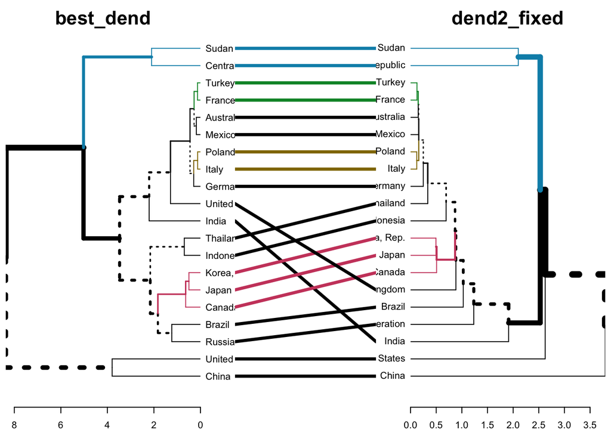

```r
untangle(dend_complete, dend_simple, method = "step1side") %>%
   tanglegram(common_subtrees_color_branches = TRUE)
```

#### Want to plot your dendrogram with ggplot instead? Me too.

Here’s how you can make your dendrogram with `ggplot` (here, I’ll use the complete linkage example stored as `hc_complete`) using `ggdendrogram()`, a `ggplot` wrapper:

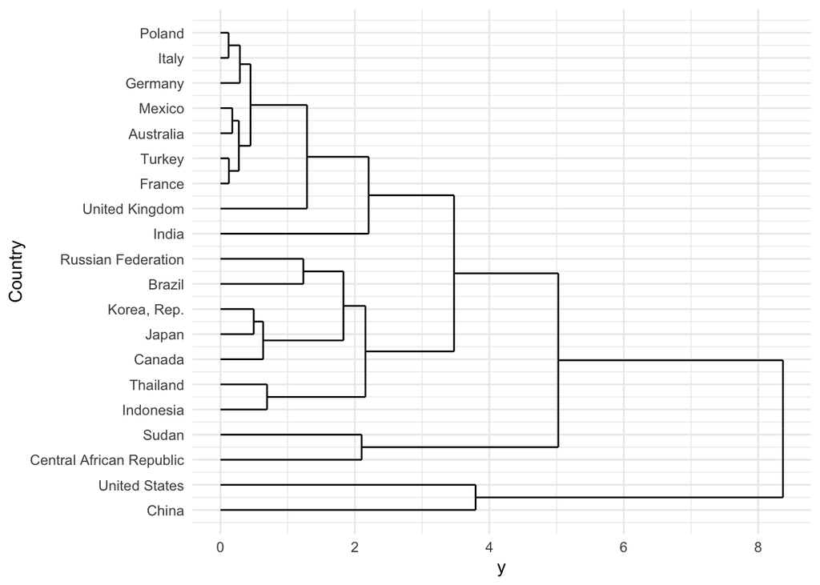

```r
ggdendrogram(hc_complete,
             rotate = TRUE) +
  theme_minimal() +
  labs(x = "Country")
```

```r
# COOL. Then you can customize w/ usual ggplot tools.
```

## End Week 6 lab